# Calculation of Timothy and Watergrass seed abundance. Summer 2019

Emilio A. Laca

2021-12-23

# 1 Add code to remove the subunits that have all zeros.

## 1.1 Names of variables

Whenever a different name is encountered for these variables, it will be corrected accordingly.

1. Refuge (for spelled-out refuge names, do not use as a key field)
2. LIT (use as the key field)
3. Unit_Name
4. Subunit_Name
5. subunit_ID (paste(LIT, Unit_Name, Subunit_Name, sep = “_“))
6. group (paste(LIT, Unit_Name, Subunit_Name, Stratum, sep = “_“))
7. Stratum (“a.Low”, “b.Med”, “c.High”)
8. LIT_Strat (factor(paste(LIT, Stratum, sep = “_“)))

## 1.2 Read RDS’s

## 1.3 Models to go from seed dimensions to mass

## 1.4 Prepare utility info

## 1.5 Read data files

```
## 'data.frame':    336 obs. of  10 variables:
##  $ LIT           : chr  "CLS" "CLS" "CLS" "CLS" ...
##  $ Unit_Name     : chr  "T13A" "T13A" "T13A" "T13A" ...
##  $ Subunit_Name  : chr  "T13A" "T13A" "T13A" "T13A" ...
##  $ Stratum       : Factor w/ 3 levels "a.Low","b.Med",..: 1 1 2 3 3 3 3 3 3 3 ...
##  $ avg_length_mm : num  7.8 10.4 9.4 8 8.6 10 9.4 8.4 22.4 12.8 ...
##  $ n_seed_head_m2: num  10489 6844 22000 42400 84000 ...
##  $ no_sh         : num  10489 6844 22000 42400 84000 ...
##  $ mass_g_m2     : num  107 119 318 455 1035 ...
##  $ subunit_ID    : chr  "CLS_T13A_T13A" "CLS_T13A_T13A" "CLS_T13A_T13A" "CLS_T13A_T13A" ...
##  $ LIT_Strat     : Factor w/ 15 levels "CLS_a.Low","CLS_b.Med",..: 1 1 2 3 3 3 3 3 3 3 ...
```

```
## 'data.frame':    189 obs. of  10 variables:
##  $ LIT           : chr  "CLS" "CLS" "CLS" "CLS" ...
##  $ Unit_Name     : chr  "T10" "T10" "T24" "T24" ...
##  $ Subunit_Name  : chr  "T10:3" "T10:3" "T24:4" "T24:4" ...
##  $ Stratum       : Factor w/ 3 levels "a.Low","b.Med",..: 1 1 1 1 1 1 2 2 2 2 ...
##  $ avg_length_mm : num  139.3 138.8 88.8 104.3 89.8 ...
##  $ n_seed_head_m2: num  30 40 120 30 460 130 240 1270 380 1890 ...
##  $ sh_mass_mg    : num  288 379 110 152 107 ...
##  $ mass_g_m2     : num  8.63 15.14 13.14 4.57 49.34 ...
##  $ subunit_ID    : chr  "CLS_T10_T10:3" "CLS_T10_T10:3" "CLS_T24_T24:4" "CLS_T24_T24:4" ...
##  $ LIT_Strat     : Factor w/ 10 levels "CLS_a.Low","CLS_b.Med",..: 1 1 1 1 1 1 2 2 2 2 ...
```

## 1.6 Area per subunit

## 1.7 Estimation of proportions of areas

Proportion of areas

See http://www.analyticalgroup.com/download/WEIGHTED_MEAN.pdf for var(weighted average) and AREA FRAME DESIGN.pdf

## 1.8 Function to estimate mass per unit area in each stratum

The bootstrapping and calculation of final estimates with quadrat variance can be sped up by using matrix multiplication. The bootstrapping only produces mass/area for each species by LIT_strat. Mass per unit area for each subunit is then simply the multiplication of this vector times the matrix of proportions of area for each subunit. For example, there are 3 values of mass/area for st in LITx. Say that LITx has 20 subunits. There is then a matrix of proportion of low, medium and high st in each subunit of LITx. This matrix A has 3 columns and 20 rows. The vector of mass per unit area in each subunit is A(20 x 3) %*% X(3 x 1) where X is the vector with the estimates for st in LITx low med and high.

```
##      Stratum
## LIT   a.Low b.Med c.High
##   CLS    31    30     33
##   KRN     0     0      1
##   SAC    22    27     22
##   SLW     8     9      6
```

Make a data frame with the seed mass per unit area for each stratum, and species (columns) for each subunit (rows). `seed_mass_fun` is a function that takes the file `p_Area`, and the models for g.m2 by Subunit_Name and Stratum (“st_rlm3” and “wg_rlm3”) as arguments and yields the seed mass of st and wg per unit area of each subunit, and the area of each subunit. The resulting file can be used to calculate refuge-level yields.

## 1.9 Mass per subunit and refuge

### 1.9.1 Mass per subunit is given as average g/m2 over the whole subunit area.

```
## tibble [82 × 14] (S3: tbl_df/tbl/data.frame)
##  $ LIT           : chr [1:82] "CLS" "CLS" "CLS" "CLS" ...
##  $ Unit_Name     : chr [1:82] "T10" "T13A" "T15" "T15" ...
##  $ Subunit_Name  : chr [1:82] "T10:3" "T13A" "T15:1" "T15:2" ...
##  $ subunit_ID    : chr [1:82] "CLS_T10_T10:3" "CLS_T13A_T13A" "CLS_T15_T15:1" "CLS_T15_T15:2" ...
##  $ st_g_m2_a.Low : num [1:82] 58.1 58.1 58.1 58.1 58.1 ...
##  $ st_g_m2_b.Med : num [1:82] 282 282 282 282 282 ...
##  $ st_g_m2_c.High: num [1:82] 747 747 747 747 747 ...
##  $ wg_g_m2_a.Low : num [1:82] 13 13 13 13 13 ...
##  $ wg_g_m2_b.Med : num [1:82] 50.8 50.8 50.8 50.8 50.8 ...
##  $ wg_g_m2_c.High: num [1:82] 65.5 65.5 65.5 65.5 65.5 ...
##  $ wg_g_m2       : num [1:82] 6.4845 0 0.0113 0 0 ...
##  $ st_g_m2       : num [1:82] 169 568 419 0 0 ...
##  $ tot_g_m2      : num [1:82] 176 568 419 0 0 ...
##  $ area_ha       : num [1:82] 17.4 36 14.2 16.7 30 ...
##  - attr(*, "notes")= chr "These estimations exclude the uncertainty due to the proportion of area covered by each stratum in each unit, a"| __truncated__
```

Average seed mass per subunit area. Total mass of seed estimated for the subunit divided by the total area of the subunit. These estimations exclude the uncertainty due to the proportion of area covered by each stratum in each unit, and the uncertainty of the model to convert seed number and seed length into mass.

| LIT | Unit_Name | Subunit_Name | wg_g_m2 | st_g_m2 | tot_g_m2 | area_ha |
| --- | --- | --- | --- | --- | --- | --- |
| CLS | T10 | T10:3 | 6.5 | 169.5 | 176.0 | 17.4 |
| CLS | T13A | T13A | 0.0 | 567.9 | 567.9 | 36.0 |
| CLS | T15 | T15:1 | 0.0 | 419.0 | 419.0 | 14.2 |
| CLS | T15 | T15:2 | 0.0 | 0.0 | 0.0 | 16.7 |
| CLS | T15 | T15:3 | 0.0 | 0.0 | 0.0 | 30.0 |
| CLS | T15 | T15:4 | 0.0 | 0.0 | 0.0 | 30.8 |
| CLS | T17 | T17 | 0.0 | 410.2 | 410.3 | 34.9 |
| CLS | T24 | T24:4 | 36.7 | 1.3 | 38.0 | 13.7 |
| CLS | T24 | T24:5 | 34.2 | 0.0 | 34.2 | 11.4 |
| CLS | T27 | T27.3 | 0.0 | 0.0 | 0.0 | 71.6 |
| CLS | T5 | T5 | 0.0 | 0.0 | 0.0 | 39.5 |
| CLS | T6 | T6:1 | 47.4 | 2.5 | 49.9 | 10.8 |
| CLS | T6 | T6:2 | 41.2 | 0.0 | 41.2 | 13.8 |
| CLS | T6 | T6:3 | 39.5 | 1.0 | 40.5 | 18.4 |
| CLS | T6 | T6:4 | 45.6 | 0.0 | 45.6 | 11.6 |
| CLS | T6A | T6A | 0.0 | 0.0 | 0.0 | 16.7 |
| KRN | 14 | 14-F | 0.0 | 21.6 | 21.6 | 41.5 |
| KRN | 14 | 14A-1 | 0.0 | 3.3 | 3.3 | 24.5 |
| KRN | 14 | 14A-2 | 0.0 | 3.2 | 3.2 | 21.7 |
| KRN | 14 | 14B-1 | 0.0 | 80.6 | 80.6 | 30.6 |
| KRN | 14 | 14B-2 | 0.0 | 33.1 | 33.1 | 37.1 |
| KRN | 14 | 14C-1 | 0.0 | 76.4 | 76.4 | 37.5 |
| KRN | 14 | 14C-2 | 0.0 | 173.4 | 173.4 | 23.8 |
| KRN | 14 | 14D-1 | 0.0 | 21.1 | 21.1 | 33.4 |
| KRN | 14 | 14D-2 | 0.0 | 2.9 | 2.9 | 25.7 |
| KRN | 14 | 14E-1 | 0.0 | 10.0 | 10.0 | 34.8 |
| KRN | 14 | 14E-2 | 0.0 | 0.0 | 0.0 | 33.0 |
| KRN | 14 | 14G-1 | 0.0 | 130.4 | 130.4 | 53.9 |
| KRN | 14 | 14G-2 | 0.0 | 17.7 | 17.7 | 48.5 |
| KRN | 4A | 4A-1 | 0.0 | 34.1 | 34.1 | 19.5 |

[output cut: 52 more lines]

### 1.9.2 Calculate mass per refuge (kg) based on original sample.

Total seed mass in each refuge, areas and seed mass per unit area. These estimations exclude the uncertainty due to the proportion of area covered by each stratum in each unit, and the uncertainty of the model to convert seed number and seed length into mass.

| LIT | tot_mass_kg_lit | st_mass_kg_lit | wg_mass_kg_lit | tot_ha | tot_kg.ha | st_kg.ha | wg_kg.ha | year |
| --- | --- | --- | --- | --- | --- | --- | --- | --- |
| CLS | 470794 | 437427 | 33367 | 387 | 1215 | 1129 | 86 | 2019 |
| KRN | 653572 | 653572 | 0 | 860 | 760 | 760 | 0 | 2019 |
| PIX | 727841 | 727841 | 0 | 312 | 2333 | 2333 | 0 | 2019 |
| SAC | 119364 | 84159 | 35205 | 190 | 627 | 442 | 185 | 2019 |
| SLW | 72631 | 59707 | 12924 | 124 | 588 | 483 | 105 | 2019 |

## 1.10 Mass estimates and distributions with quadrat variance.

Seed yield, confidence intervals. etc. for each subunit and refuge are calculated by resampling yield per stratum for each subunit. For each species, individual quadrats are resampled within refuge and stratum.

Using `tidymodels` and `rsample`.

```
##    user  system elapsed
## 184.552   2.146 187.325
```

The tibble qdt_bt contains original data, 4000 bootstrap samples of wg quadrats, 4000 bootstrap samples of st quadrats, and the corresponding estimates of mass_m2 in each subunit for each species and total.

The bootstrap samples are then summarized to produce percentile confidence intervals and averages of st, wg and total mass per m2. The code calculates univariate statistics, but covariances over bootstrap samples could be calculated at this stage.

```
## # A tibble: 82 × 10
##    subunit_ID    wg_q10 wg_mean  wg_q90  st_q10 st_mean  st_q90 tot_q10 tot_mean
##    <chr>          <dbl>   <dbl>   <dbl>   <dbl>   <dbl>   <dbl>   <dbl>    <dbl>
##  1 CLS_T10_T10… 5.72e+0  6.51    7.40   148.    169.    189.     154.     176.
##  2 CLS_T13A_T1… 0        0       0      490.    566.    637.     490.     566.
##  3 CLS_T15_T15… 9.35e-3  0.0113  0.0136 367.    418.    467.     367.     418.
##  4 CLS_T15_T15… 0        0       0        0       0       0        0        0
##  5 CLS_T15_T15… 0        0       0        0       0       0        0        0
##  6 CLS_T15_T15… 0        0       0        0       0       0        0        0
##  7 CLS_T17_T17  1.83e-2  0.0221  0.0261 360.    409.    458.     360.     409.
##  8 CLS_T24_T24… 3.24e+1 36.7    41.2      1.09    1.28    1.46    33.7     38.0
##  9 CLS_T24_T24… 2.99e+1 34.2    38.8      0       0       0       29.9     34.2
## 10 CLS_T27_T27… 0        0       0        0       0       0        0        0
## 11 CLS_T5_T5    0        0       0        0       0       0        0        0
## 12 CLS_T6_T6:1  4.12e+1 47.4    54.1      2.10    2.54    2.99    43.8     49.9
```

[output cut: 71 more lines]

In this section, the bootstrap samples are used to estimate total mass of seed heads per refuge.

## 1.11 Mass estimates with quadrat and area variance

Mass per m2 of subunit area is a weighted average of mass per m2 in each stratum, where the weights are the proportions of the subunit area covered by each stratum, including nonfood areas. Thus, the estimated mass per m2 has variance due to the variance of mass per m2 (quadrat sampling variance and seed head model variance) in each stratum plus variance of the estimated proportion of area in each stratum.

### 1.11.1 Sum of products of independent variables

This approach is approximate because it assumes that composition variables are independent, but it includes the correction for finite population.

The formula used is:

$$\sigma^2_{\sum(X_i Y_i)} = \sum{\left((\sigma^2_{X_i} + \mu^2_{X_i})(\sigma^2_{Y_i} + \mu^2_{Y_i}) - \mu^2_{X_i} \mu^2_{Y_i}\right)}$$

where $X_i$ are the values of mass per unit area for each stratum and the $Y_i$ are the proportions of each stratum in the subunit. The variances of $X_i$ are obtained from the bootstrapped data and the variances of $Y_i$ are given by the calculation of `v_Area_c`.

Confidence intervals are calculated assuming a normal distribution.

```
## # A tibble: 82 × 9
##    LIT   Unit_Name    Subunit_Name wg_g_m2 st_g_m2 CI80lwr tot_g_m2 CI80upr
##    <chr> <chr>        <chr>          <dbl>   <dbl>   <dbl>    <dbl>   <dbl>
##  1 CLS   T6           T6:2         41.2      0      36.0      41.2    46.5
##  2 CLS   T10          T10:3         6.48   169.    151.      176.    201.
##  3 CLS   T6           T6:4         45.6      0      39.2      45.6    51.9
##  4 PIX   4A           4A            0      264.    225.      264.    302.
##  5 CLS   T24          T24:5        34.2      0      28.3      34.2    40.0
##  6 KRN   4A           4A-6          0      110.     90.5     110.    129.
##  7 CLS   T13A         T13A          0      568.    464.      568.    672.
##  8 KRN   6A           6A-5          0      125.    102.      125.    148.
##  9 CLS   T17          T17           0.0221 410.    331.      410.    490.
## 10 KRN   14           14G-1         0      130.    106.      130.    155.
## 11 PIX   4            4             0      263.    213.      263.    313.
## 12 KRN   5B           5B-6          0      119.     95.6     119.    143.
```

[output cut: 71 more lines]

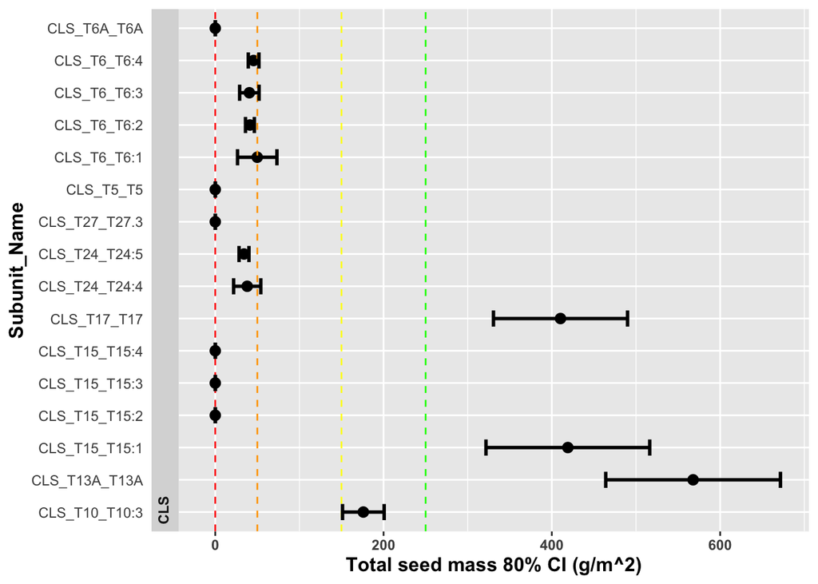

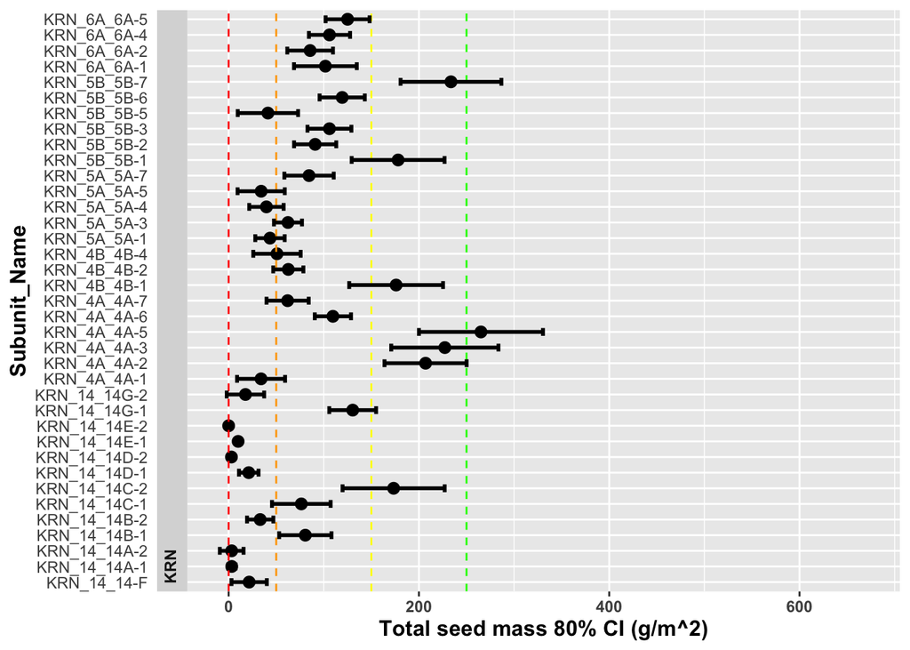

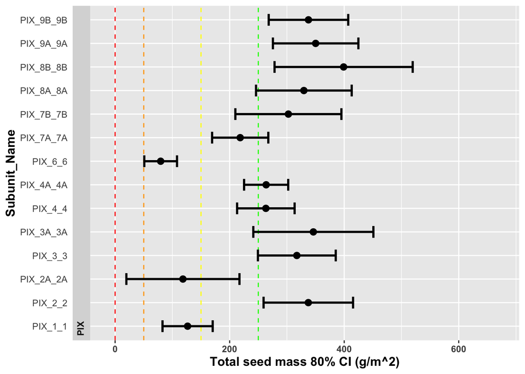

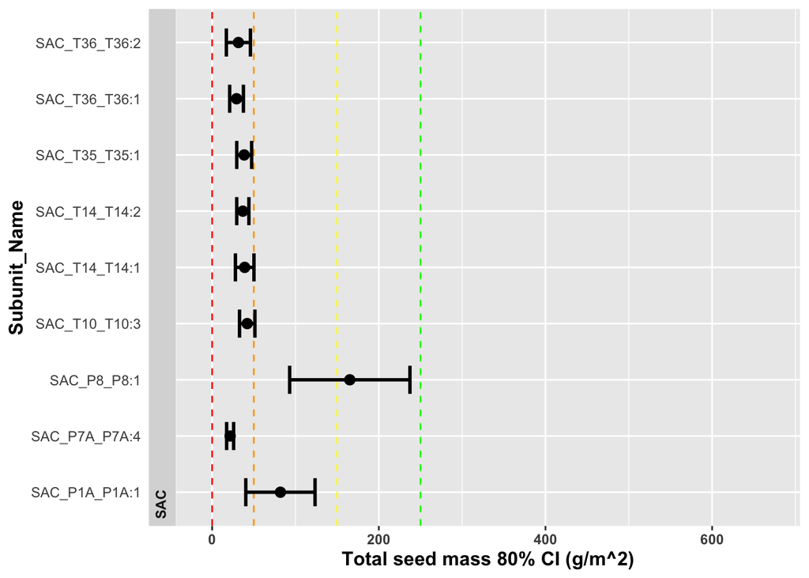

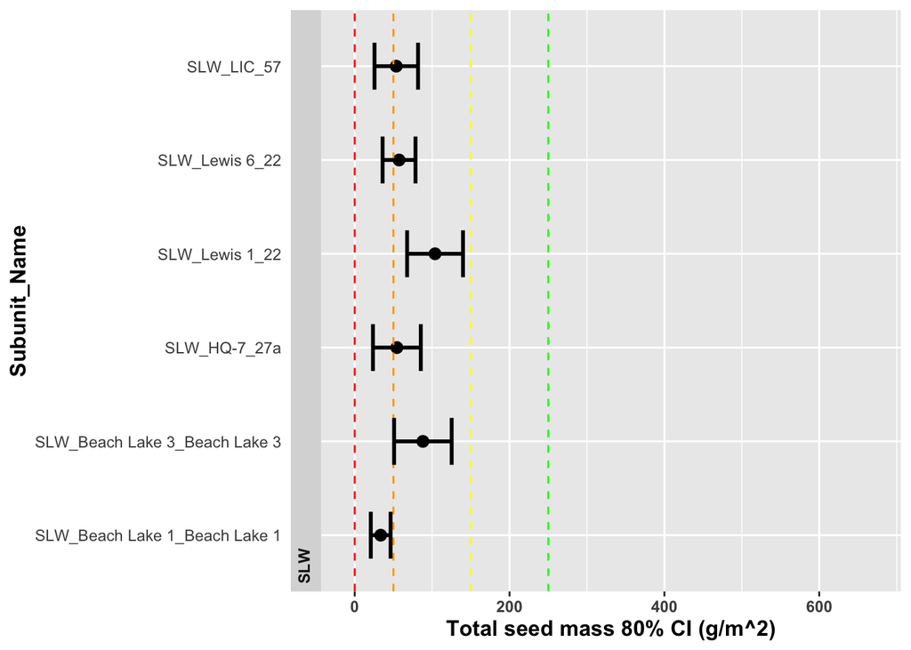

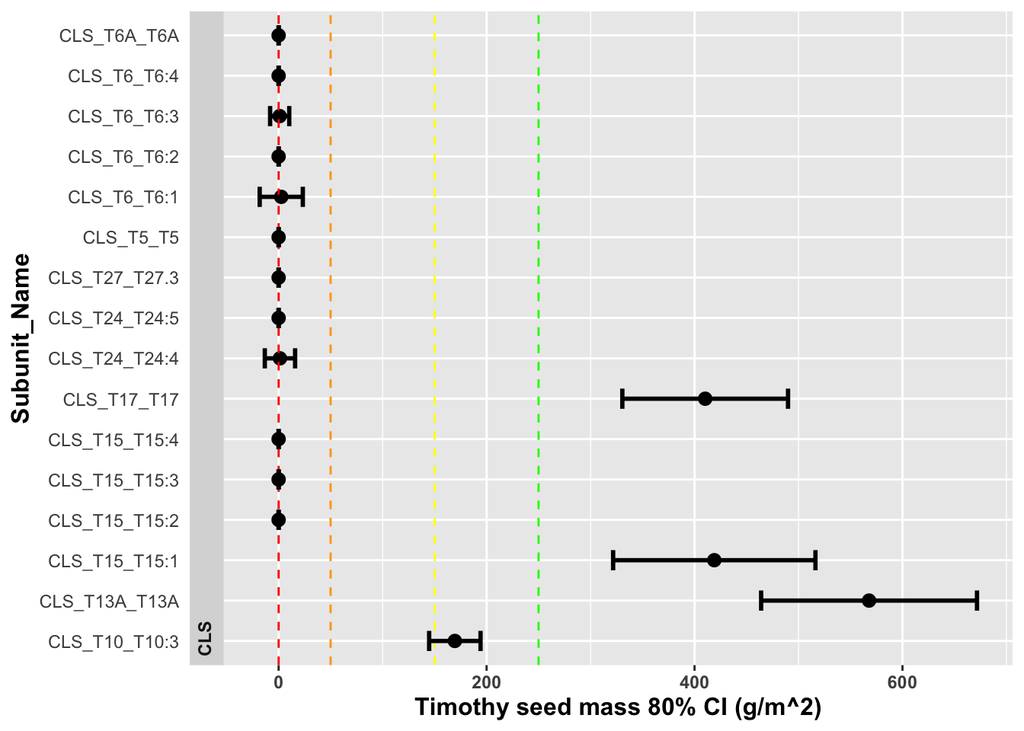

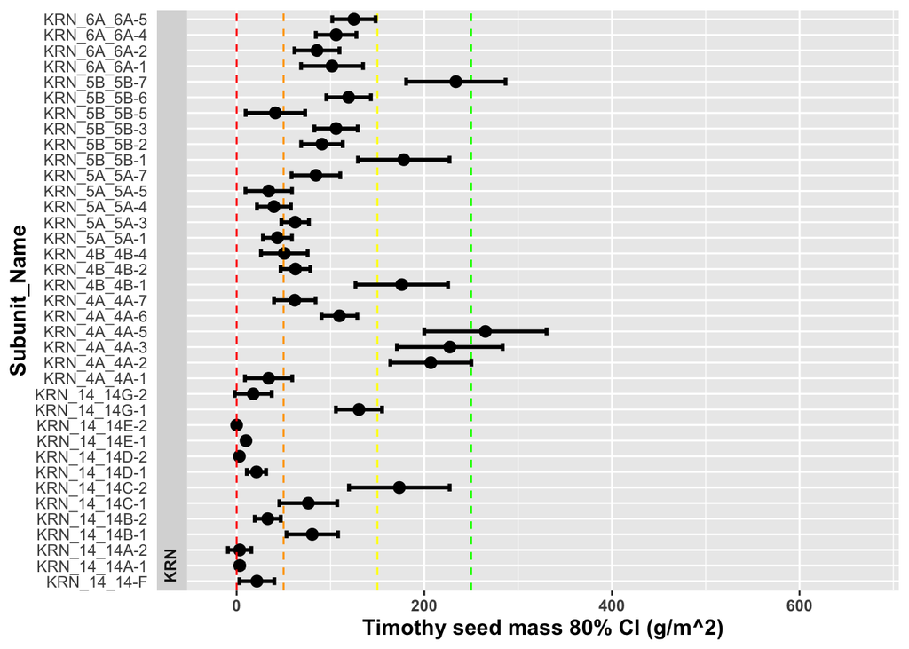

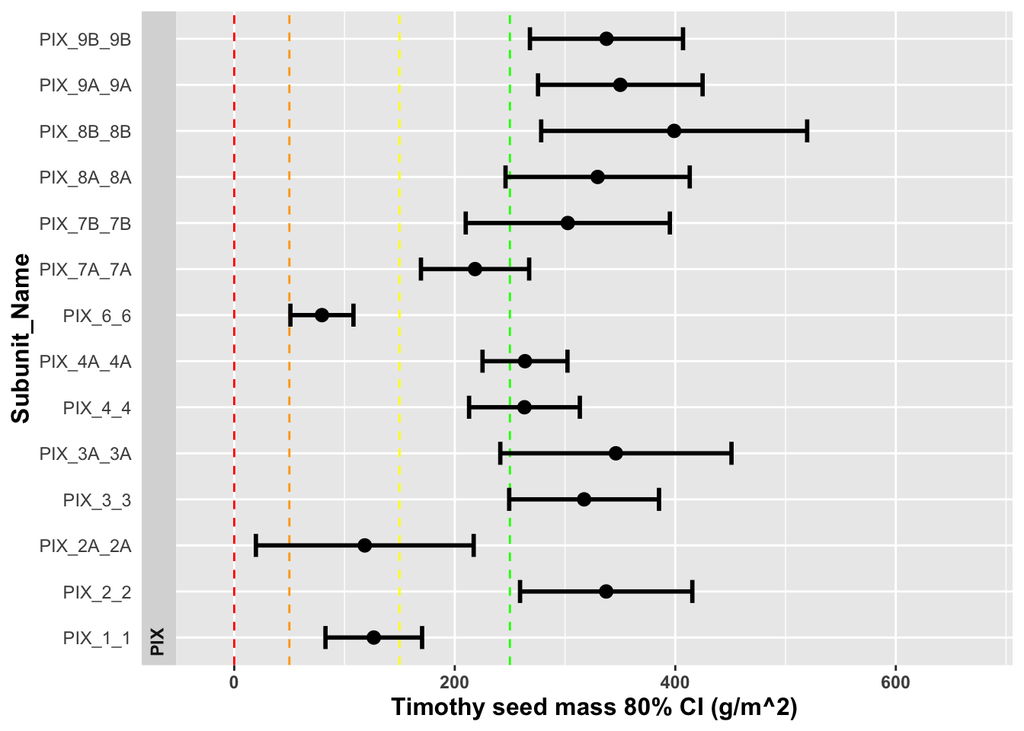

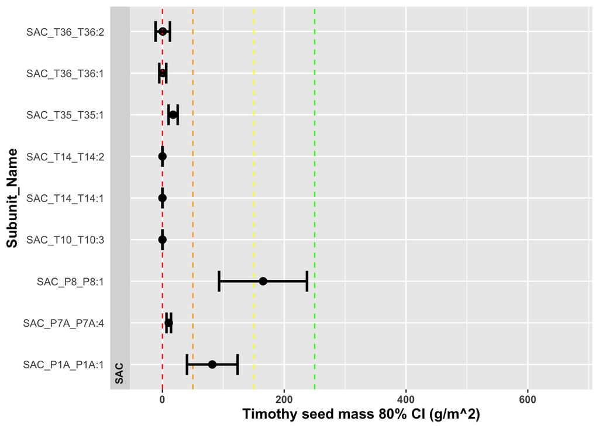

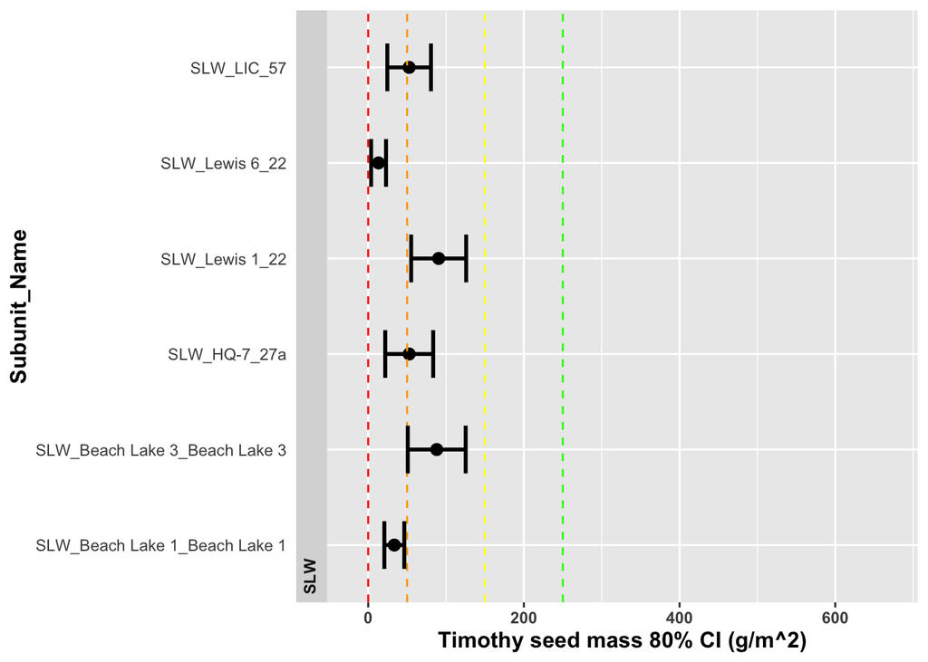

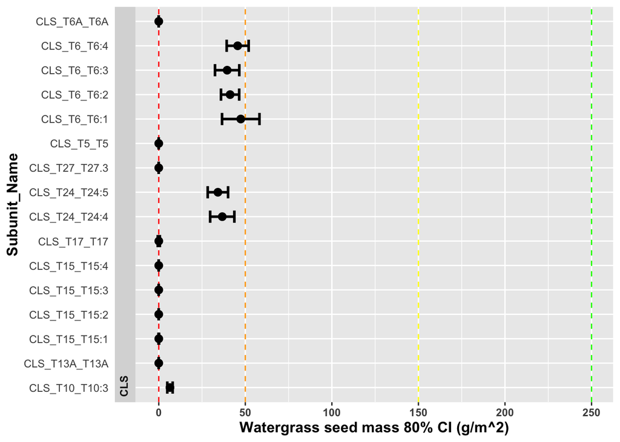

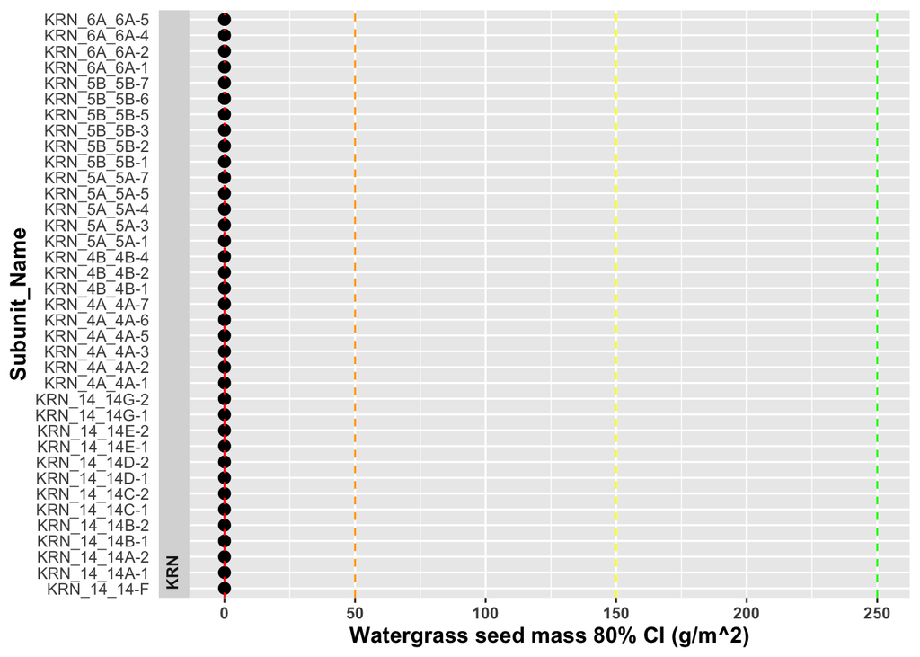

[3 more figures not shown]

## 1.13 Test of differences in mass/m.sq among units within refuge

Variance of differences is approximated by assuming that estimates compared are independent from each other. This assumption may be weak because the estimates for different subunits are based on the same estimates for mass/m2 for the different strata.

## 1.14 Test of differences in mass and mass/m.sq among refuges

[output not shown]

[output cut: 928 more lines]

```
## [1] "Proportion of area in each stratum by subunit"
```

```
## # A tibble: 82 × 8
##    subunit_ID            p_wg_a.Low p_wg_b.Med p_wg_c.High p_st_a.Low p_st_b.Med
##    <chr>                      <dbl>      <dbl>       <dbl>      <dbl>      <dbl>
##  1 CLS_T10_T10:3           0.284       0.0551     0          0          0.130
##  2 CLS_T13A_T13A           0           0          0          0.0526     0.202
##  3 CLS_T15_T15:1           0.000870    0          0          0.0937     0.307
##  4 CLS_T15_T15:2           0           0          0          0          0
##  5 CLS_T15_T15:3           0           0          0          0          0
##  6 CLS_T15_T15:4           0           0          0          0          0
##  7 CLS_T17_T17             0           0          0.000338   0.129      0.308
##  8 CLS_T24_T24:4           0.116       0.306      0.300      0          0
##  9 CLS_T24_T24:5           0.0981      0.203      0.345      0          0
## 10 CLS_T27_T27.3           0           0          0          0          0
## 11 CLS_T5_T5               0           0          0          0          0
## 12 CLS_T6_T6:1             0.123       0.230      0.520      0          0.00761
```

[output cut: 71 more lines]

```
## [1] "Mean seed mass per area for Timothy"
```

```
##  LIT_Strat  emmean    SE df asymp.LCL asymp.UCL
##  CLS_a.Low    8.55 2.064 NA      4.50     12.59
##  CLS_b.Med   16.48 1.685 NA     13.18     19.78
##  CLS_c.High  23.86 1.191 NA     21.53     26.20
##  KRN_a.Low   10.66 0.530 NA      9.62     11.70
##  KRN_b.Med   16.46 0.820 NA     14.85     18.06
##  KRN_c.High  19.06 1.054 NA     17.00     21.13
##  PIX_a.Low   14.86 0.789 NA     13.31     16.41
##  PIX_b.Med   20.75 0.973 NA     18.84     22.65
##  PIX_c.High  20.28 1.685 NA     16.98     23.58
##  SAC_a.Low    7.60 2.527 NA      2.65     12.55
##  SAC_b.Med   10.47 1.402 NA      7.72     13.22
##  SAC_c.High  15.51 2.261 NA     11.08     19.94
##  SLW_a.Low    4.30 1.264 NA      1.82      6.78
##  SLW_b.Med   10.19 1.305 NA      7.64     12.75
##  SLW_c.High  15.27 1.103 NA     13.11     17.43
##
## Results are given on the bcPower (not the response) scale.
## Confidence level used: 0.95
```

```
## [1] "Mean seed mass per area for Watergrass"
```

```
##  LIT_Strat  emmean    SE df asymp.LCL asymp.UCL
##  CLS_a.Low    3.05 0.246 NA      2.56      3.53
##  CLS_b.Med    5.14 0.250 NA      4.65      5.63
##  CLS_c.High   5.57 0.238 NA      5.10      6.04
##  SAC_a.Low    3.40 0.292 NA      2.83      3.97
##  SAC_b.Med    4.61 0.263 NA      4.09      5.12
##  SAC_c.High   5.17 0.292 NA      4.60      5.75
##  SLW_a.Low    3.91 0.484 NA      2.96      4.86
##  SLW_b.Med    4.31 0.456 NA      3.41      5.20
##  SLW_c.High   5.96 0.559 NA      4.86      7.05
##
## Results are given on the bcPower (not the response) scale.
## Confidence level used: 0.95
```

## 1.15 Save objects for demo shiny app